# Online Retail Data Time Series Predictive Modeling

Kimberly Healy | healy.kim@gmx.us

## Background

The data ([OnlineRetail.csv](https://archive.ics.uci.edu/ml/datasets/Online+Retail)) come from all transactions occurring between 01/12/2010 and 09/12/2011 for a UK-based online retail store. The company mainly sells unique gifts and the majority of customers are wholesalers. This report will use techniques to explore the data and use three different time series algorithms to model sales. The conclusion states which model(s) best predict sales and recommendations for further analysis.

The following predictive models are used:  
**Model 1: Simple Moving Average**: a weighted average function that identifies the previous pattern in the data and uses that pattern to predict future data points.  
**Model 2: Exponential Smoothing**: similar to Simple Moving Average, but contains a smoothing constant which can be tweaked for more responsive or more stable models.  
**Model 3: Autoregressive Integrated Moving Average (ARIMA)**: unlilke the previous models, ARIMA considers the correlations among the previous values of the time series to predict future values.

The following question is answered:  
- **Which model best predicts company sales?**

## I. Load required libraries

```r
library(tidyverse)
library(bpa)
library(forecast)
library(ggplot2)
library(knitr)
library(kableExtra)
library(moments)
```

## II. Load raw data from Excel file

```r
retail_raw <- readxl::read_excel("OnlineRetail.xlsx")
retail <- retail_raw%>%
    mutate(across(where(is.character), as.factor))%>%
    mutate(Sales = (Quantity*UnitPrice))
retail$CustomerID<-as.factor(retail$CustomerID)
```

## III. Define Useful Functions

### (i) Moving Average with Prediction

Source: Quanghau (Robin) Qiu, Professor of Informational Science, Penn State Engineering

```r
movavg_pred <- function(x, n, type=c("s", "e"), h=0) {
stopifnot(is.numeric(x), is.numeric(n), is.character(type),is.numeric(h))
if (length(n) != 1 || ceiling(n != floor(n)) || n <= 1)
stop("Window length 'n' must be a single integer greater 1.")
nx <- length(x)
if (n >= nx)
stop("Window length 'n' must be greater then length of time series.")
y <- numeric(nx)
if (type == "s") { # simple
for (k in 1:(n-1)) y[k] <- mean(x[1:k])
for (k in n:nx) y[k] <- mean(x[(k-n+1):k])

# adding h forecasting points based on the Moving Average equation
if (h>0) {
for (k in 1:h) {
y[nx+k] <- mean(x[(nx-n-1+k):(nx-1+k)])
x[nx+k] <- y[nx+k]
}
}
} else if (type == "e") { # exponential
a <- 2/(n+1)
y[1] <- x[1]
for (k in 2:nx) y[k] <- a*x[k] + (1-a)*y[k-1]

# adding h forecasting points based on the Exponential Smoothing equation
if (h>0) {
y[nx] <- x[nx]
for (k in 1:h) {
y[nx+k] <- a*x[nx+k-1] + (1-a)*y[nx+k-2]
x[nx+k] <- y[nx+k]
}
}
} else
stop("The type must be one of 's' or 'e'")
return(y)
}
```

The “n” input for the movavg_pred function used for the Simple Moving Average and Exponential Smoothing models indicates how many previous data points (previous months) are considered in the forecast. The larger to n, the more previous data points (months) are considered, and typically the higher accuracy of the forecast.

## IV. Data Exploration

### (i) Basic Exploration

#### Summary

The data set dimensions are 541,909 rows by 8 attributes.  
There are negative numbers for Quantity and UnitPrice. Sales is derived from Quantity and UnitPrice, so it’s worth looking into.

```r
dim(retail)
```

```
## [1] 541909      9
```

```r
str(retail)
```

```
## tibble [541,909 × 9] (S3: tbl_df/tbl/data.frame)
##  $ InvoiceNo  : Factor w/ 25900 levels "536365","536366",..: 1 1 1 1 1 1 1 2 2 3 ...
##  $ StockCode  : Factor w/ 4070 levels "10002","10080",..: 3538 2795 3045 2986 2985 1663 801 1548 1547 3306 ...
##  $ Description: Factor w/ 4211 levels "?","? sold as sets?",..: 4014 4022 919 1947 2967 3221 1560 1685 1682 248 ...
##  $ Quantity   : num [1:541909] 6 6 8 6 6 2 6 6 6 32 ...
##  $ InvoiceDate: POSIXct[1:541909], format: "2010-12-01 08:26:00" "2010-12-01 08:26:00" ...
##  $ UnitPrice  : num [1:541909] 2.55 3.39 2.75 3.39 3.39 7.65 4.25 1.85 1.85 1.69 ...
##  $ CustomerID : Factor w/ 4372 levels "12346","12347",..: 4049 4049 4049 4049 4049 4049 4049 4049 4049 541 ...
##  $ Country    : Factor w/ 38 levels "Australia","Austria",..: 36 36 36 36 36 36 36 36 36 36 ...
##  $ Sales      : num [1:541909] 15.3 20.3 22 20.3 20.3 ...
```

```r
summary(retail)
```

```
##    InvoiceNo        StockCode                                  Description
##  573585 :  1114   85123A :  2313   WHITE HANGING HEART T-LIGHT HOLDER:  2369
##  581219 :   749   22423  :  2203   REGENCY CAKESTAND 3 TIER          :  2200
##  581492 :   731   85099B :  2159   JUMBO BAG RED RETROSPOT           :  2159
##  580729 :   721   47566  :  1727   PARTY BUNTING                     :  1727
##  558475 :   705   20725  :  1639   LUNCH BAG RED RETROSPOT           :  1638
##  579777 :   687   84879  :  1502   (Other)                           :530362
##  (Other):537202   (Other):530366   NA's                              :  1454
##     Quantity          InvoiceDate                    UnitPrice
##  Min.   :-80995.00   Min.   :2010-12-01 08:26:00   Min.   :-11062.06
##  1st Qu.:     1.00   1st Qu.:2011-03-28 11:34:00   1st Qu.:     1.25
##  Median :     3.00   Median :2011-07-19 17:17:00   Median :     2.08
##  Mean   :     9.55   Mean   :2011-07-04 13:34:57   Mean   :     4.61
##  3rd Qu.:    10.00   3rd Qu.:2011-10-19 11:27:00   3rd Qu.:     4.13
##  Max.   : 80995.00   Max.   :2011-12-09 12:50:00   Max.   : 38970.00
##
##    CustomerID               Country           Sales
##  17841  :  7983   United Kingdom:495478   Min.   :-168469.60
##  14911  :  5903   Germany       :  9495   1st Qu.:      3.40
##  14096  :  5128   France        :  8557   Median :      9.75
##  12748  :  4642   EIRE          :  8196   Mean   :     17.99
##  14606  :  2782   Spain         :  2533   3rd Qu.:     17.40
##  (Other):380391   Netherlands   :  2371   Max.   : 168469.60
##  NA's   :135080   (Other)       : 15279
```

#### NAs

```r
print(length(which(is.na(retail))))
```

```
## [1] 136534
```

```r
print(colSums(is.na(retail)))
```

```
##   InvoiceNo   StockCode Description    Quantity InvoiceDate   UnitPrice
##           0           0        1454           0           0           0
##  CustomerID     Country       Sales
##      135080           0           0
```

#### UnitPrice & Quantity

There are negative numbers for Quantity and UnitPrice. Sales is derived from Quantity and UnitPrice, so it’s worth looking into.

- There are 2,515 instances where **UnitPrice is 0**: All of these instances indicate that the company ate the cost of a damaged, lost, or returned item; payment was by check; or an inventory adjustment needed to be made. Descriptions range from “wrongly coded” to “Wet pallet-thrown away” to “reverse 21/5/10 adjustment”.
- There are 2 instances where **UnitPrice is negative**: Both of these are adjustments for bad debt.
- There are 9,288 instances where **Quantity is negative and UnitPrice is greater than 0**: The majority indicate return of product, and some indicate a transaction fee, discount, or commission.

It is worth investigating the effect of any transaction that is not directly related to sales of product, such as various business expenses, in the data set.

```r
nrow(retail%>%filter(UnitPrice == 0))
```

```
## [1] 2515
```

```r
nrow(retail%>%filter(UnitPrice < 0))
```

```
## [1] 2
```

```r
nrow(retail%>%filter(Quantity <= 0 & UnitPrice > 0))
```

```
## [1] 9288
```

#### Biz Expenses

It is worth investigating the effect of any transaction that is not directly related to sales of product, such as various business expenses, in the data set.

To investigate transactions in the data that are not related to sales, I used pattern analysis on the StockCode attribute. The output shows the 16 unique patterns of StockCode and the frequencies of the pattern. I extracted the StockCode values using match_pattern() - two examples are shown below - and found that there are three StockCode types in the data: product sales or returns, business expenses, or ambiguous whether it is a sale or expense.

In a perfect world, sales, returns, and other expenses are separated into three distinct categories. **However, based on the information that I have, there is too much ambiguity surrounding the categorization of transactions.**

**The best course of action will be to separate the analysis into sales that are positive and sales that are negative. Predicting money coming in (positive Sales attribute) and money going out (negative Sales attribute) is more informative than not separating them.**

```r
retail$StockCode %>%
    as.character()%>%
    get_pattern %>%
    table
```

```
## .
##        99999       99999a       99999A      99999aa      99999AA            a
##       487036         1880        49608           62          328            1
##            A           A9          AAA         AAAA aaaa_9999_99     AAAA9999
##          714          144          710         1276           34           20
##    AAAA9999A     AAAAAAAA    AAAAAAAAA AAAAwAAAAAAA
##            1           11           47           37
```

```r
retail$StockCode %>%
    as.character()%>%
    match_pattern(pattern = "AAAAAAAAA", unique_only=TRUE)
```

```
## [1] "AMAZONFEE" "DCGSSGIRL"
```

```r
retail$StockCode %>%
    as.character()%>%
    match_pattern(pattern = "AAAAwAAAAAAA", unique_only=TRUE)
```

```
## [1] "BANK CHARGES"
```

```r
# divide the data set by positive and negative Sales.
retail_pos<-retail%>%filter(Sales > 0)
retail_neg<-retail%>%filter(Sales <= 0)
```

### (ii) Sales Exploration

#### Group by Week

Group positive and negative sales by week.

```r
retail_pos_Weekly <- retail_pos %>%
  group_by(`Year-Week` = format(InvoiceDate, '%Y-%U'))%>%
  summarise_if(is.numeric, sum)


retail_pos_Weekly%>%kable(digits = 2, format = "html", row.names = TRUE,caption = "Positive Sales by Week") %>%
  kable_styling(bootstrap_options = c("striped", "hover"),
                full_width = F,
                font_size = 12,
                position = "left")%>%
  column_spec(column = 1:2, bold = TRUE)%>%
  scroll_box(width = "100%", height = "300px")
```

Positive Sales by Week

|  | Year-Week | Quantity | UnitPrice | Sales |
| --- | --- | --- | --- | --- |
| 1 | 2010-48 | 74447 | 30471.27 | 153652.88 |
| 2 | 2010-49 | 127609 | 92376.39 | 344382.69 |
| 3 | 2010-50 | 113997 | 49573.83 | 225806.36 |
| 4 | 2010-51 | 43186 | 27482.98 | 99904.21 |
| 5 | 2011-01 | 68698 | 21590.68 | 117879.99 |
| 6 | 2011-02 | 93463 | 35575.04 | 201898.18 |
| 7 | 2011-03 | 143760 | 34337.82 | 212374.99 |
| 8 | 2011-04 | 65018 | 29968.87 | 128955.29 |
| 9 | 2011-05 | 70833 | 29608.58 | 129149.32 |
| 10 | 2011-06 | 50902 | 22712.82 | 104824.18 |
| 11 | 2011-07 | 78810 | 24748.15 | 139823.40 |
| 12 | 2011-08 | 85080 | 28925.88 | 148808.97 |
| 13 | 2011-09 | 69237 | 28735.35 | 132238.68 |
| 14 | 2011-10 | 71670 | 32715.55 | 141077.78 |
| 15 | 2011-11 | 76405 | 31007.20 | 143686.25 |
| 16 | 2011-12 | 87799 | 33036.98 | 162567.61 |
| 17 | 2011-13 | 105685 | 35094.13 | 195018.68 |
| 18 | 2011-14 | 68416 | 34629.62 | 131513.05 |
| 19 | 2011-15 | 84988 | 26626.44 | 146760.16 |
| 20 | 2011-16 | 89101 | 32766.44 | 154376.48 |
| 21 | 2011-17 | 47816 | 17057.39 | 79491.42 |
| 22 | 2011-18 | 71096 | 31372.51 | 135047.86 |
| 23 | 2011-19 | 115849 | 43813.22 | 220927.38 |
| 24 | 2011-20 | 100344 | 34058.00 | 201528.51 |
| 25 | 2011-21 | 92562 | 34464.15 | 182923.91 |
| 26 | 2011-22 | 49164 | 22482.01 | 100443.44 |
| 27 | 2011-23 | 101990 | 38834.70 | 233274.20 |
| 28 | 2011-24 | 97932 | 28831.37 | 180207.12 |
| 29 | 2011-25 | 86436 | 35226.24 | 151332.30 |
| 30 | 2011-26 | 77240 | 24955.15 | 140266.26 |
| 31 | 2011-27 | 91977 | 38950.75 | 177359.00 |
| 32 | 2011-28 | 74574 | 27904.75 | 125941.94 |
| 33 | 2011-29 | 103324 | 42329.02 | 192460.64 |
| 34 | 2011-30 | 103344 | 27294.68 | 176293.94 |
| 35 | 2011-31 | 118807 | 27849.81 | 196614.06 |
| 36 | 2011-32 | 100450 | 44489.80 | 192093.48 |
| 37 | 2011-33 | 95022 | 20339.93 | 167158.68 |
| 38 | 2011-34 | 98897 | 25189.56 | 168711.26 |
| 39 | 2011-35 | 75813 | 37671.23 | 147743.68 |
| 40 | 2011-36 | 100207 | 32285.23 | 174311.59 |
| 41 | 2011-37 | 133185 | 39680.82 | 249903.20 |
| 42 | 2011-38 | 159414 | 48251.72 | 323144.86 |
| 43 | 2011-39 | 131673 | 40619.75 | 231538.35 |
| 44 | 2011-40 | 172455 | 49458.80 | 319097.52 |
| 45 | 2011-41 | 116847 | 45137.07 | 219289.62 |
| 46 | 2011-42 | 154464 | 49894.33 | 286328.22 |
| 47 | 2011-43 | 138003 | 52816.41 | 238323.56 |
| 48 | 2011-44 | 156515 | 55996.90 | 293522.72 |
| 49 | 2011-45 | 186666 | 68390.13 | 378921.39 |
| 50 | 2011-46 | 187424 | 73140.02 | 387633.79 |
| 51 | 2011-47 | 165604 | 75837.38 | 330859.65 |
| 52 | 2011-48 | 155778 | 73393.70 | 320360.48 |
| 53 | 2011-49 | 258400 | 81447.22 | 528931.36 |

```r
retail_neg_Weekly <- retail_neg %>%
  group_by(`Year-Week` = format(InvoiceDate, '%Y-%U'))%>%
  summarise_if(is.numeric, sum)


retail_neg_Weekly%>%kable(digits = 2, format = "html", row.names = TRUE,caption = "Negative Sales by Week") %>%
  kable_styling(bootstrap_options = c("striped", "hover"),
                full_width = F,
                font_size = 12,
                position = "left")%>%
  column_spec(column = 1:2, bold = TRUE)%>%
  scroll_box(width = "100%", height = "300px")
```

Negative Sales by Week

|  | Year-Week | Quantity | UnitPrice | Sales |
| --- | --- | --- | --- | --- |
| 1 | 2010-48 | -11780 | 362.75 | -3189.58 |
| 2 | 2010-49 | -3331 | 55813.40 | -59952.63 |
| 3 | 2010-50 | -1781 | 3943.27 | -9030.58 |
| 4 | 2010-51 | -119 | 496.96 | -2616.33 |
| 5 | 2011-01 | -3388 | 35778.44 | -39869.86 |
| 6 | 2011-02 | -3837 | 842.43 | -2309.03 |
| 7 | 2011-03 | -76804 | 3396.88 | -81761.42 |
| 8 | 2011-04 | 6121 | 2750.79 | -5988.97 |
| 9 | 2011-05 | -1901 | 577.66 | -2507.81 |
| 10 | 2011-06 | -1548 | 2538.81 | -4605.54 |
| 11 | 2011-07 | -1394 | 3672.06 | -4202.31 |
| 12 | 2011-08 | -1596 | 12731.63 | -15651.20 |
| 13 | 2011-09 | -2138 | 1351.21 | -1908.30 |
| 14 | 2011-10 | -15358 | 5222.11 | -6438.21 |
| 15 | 2011-11 | -1101 | 14241.35 | -16266.66 |
| 16 | 2011-12 | -5806 | 415.19 | -1657.15 |
| 17 | 2011-13 | -2409 | 4796.82 | -9415.09 |
| 18 | 2011-14 | -6786 | 9658.58 | -12400.61 |
| 19 | 2011-15 | -2615 | 1014.34 | -2640.81 |
| 20 | 2011-16 | -8065 | 2284.09 | -26210.93 |
| 21 | 2011-17 | -1131 | 443.71 | -2073.42 |
| 22 | 2011-18 | -2687 | 15617.45 | -16537.81 |
| 23 | 2011-19 | -7039 | 4208.30 | -6597.51 |
| 24 | 2011-20 | -2354 | 16284.87 | -17778.07 |
| 25 | 2011-21 | -3010 | 4070.49 | -5357.02 |
| 26 | 2011-22 | -1259 | 469.13 | -1822.97 |
| 27 | 2011-23 | -1698 | 40591.53 | -42320.84 |
| 28 | 2011-24 | -32981 | 2778.23 | -6066.77 |
| 29 | 2011-25 | -8144 | 15358.22 | -18060.75 |
| 30 | 2011-26 | -4069 | 1557.83 | -3780.79 |
| 31 | 2011-27 | -1581 | 905.74 | -2414.76 |
| 32 | 2011-28 | -1660 | 11534.33 | -13261.36 |
| 33 | 2011-29 | -5068 | 15724.03 | -19248.22 |
| 34 | 2011-30 | -2025 | 542.63 | -2489.25 |
| 35 | 2011-31 | -6511 | 12158.94 | -17415.62 |
| 36 | 2011-32 | -280 | -16805.13 | -28362.52 |
| 37 | 2011-33 | -3235 | 2940.78 | -5832.82 |
| 38 | 2011-34 | -6 | 12737.32 | -15343.33 |
| 39 | 2011-35 | -13331 | 1333.77 | -10158.33 |
| 40 | 2011-36 | -1568 | 859.86 | -2245.10 |
| 41 | 2011-37 | -4136 | 17503.34 | -18407.44 |
| 42 | 2011-38 | -4707 | 4397.73 | -12506.73 |
| 43 | 2011-39 | -2805 | 1266.69 | -5092.78 |
| 44 | 2011-40 | -12874 | 8133.39 | -16929.59 |
| 45 | 2011-41 | -13217 | 4614.13 | -23238.18 |
| 46 | 2011-42 | -2410 | 8301.30 | -13262.97 |
| 47 | 2011-43 | -7724 | 10148.65 | -21924.24 |
| 48 | 2011-44 | -18957 | 10054.70 | -13623.07 |
| 49 | 2011-45 | -6730 | 16791.78 | -22969.07 |
| 50 | 2011-46 | -7221 | 5242.13 | -8608.01 |
| 51 | 2011-47 | 5172 | 1698.90 | -8344.12 |
| 52 | 2011-48 | -5206 | 2216.72 | -4479.77 |
| 53 | 2011-49 | -85838 | 31785.94 | -203760.36 |

#### Correlation

The correlation between positive and negative sales is moderately negative (r=-0.573). Meaning, as sales increase the higher chance of product breakage, returns, selling fees, etc., which result in negative sales.

```r
cor(retail_pos_Weekly$Sales, retail_neg_Weekly$Sales, method="pearson")
```

```
## [1] -0.5726645
```

#### Visualizations

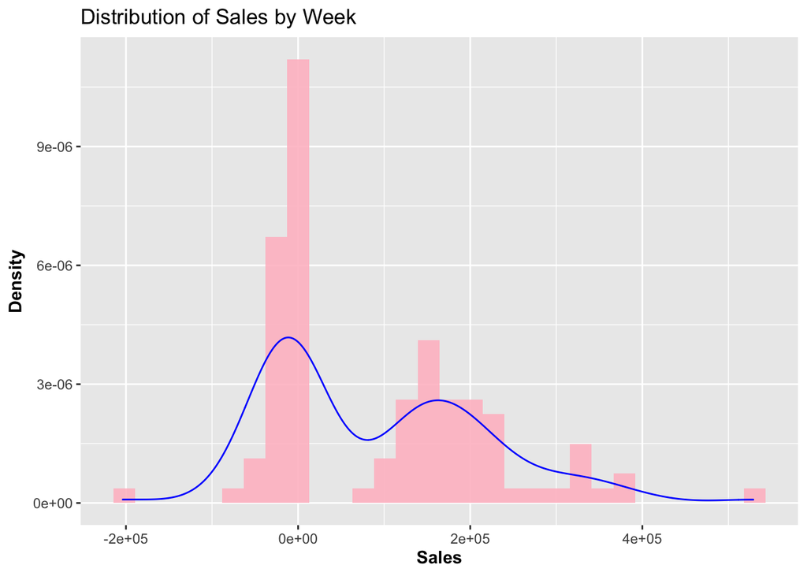

```r
# all sales by week
ggplot(bind_rows(retail_pos_Weekly, retail_neg_Weekly), aes(x = Sales)) +
    geom_histogram(aes(y = ..density..), fill = 'pink', alpha = 0.9) +
    geom_density(colour = 'blue') +
    xlab(expression(bold('Sales'))) +
    ylab(expression(bold('Density'))) +
    ggtitle("Distribution of Sales by Week")
```

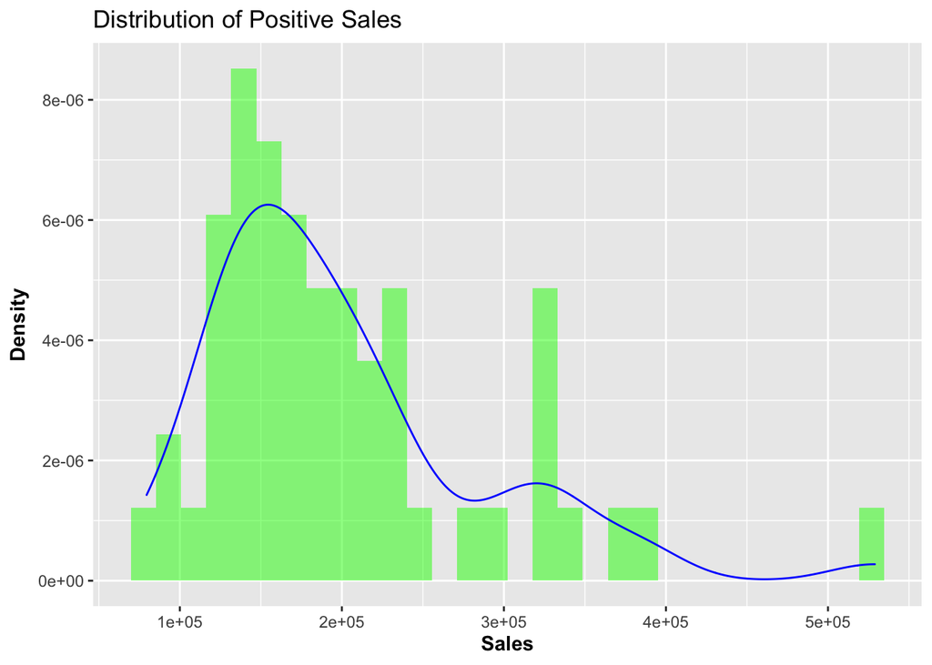

```r
# positive sales
ggplot(retail_pos_Weekly, aes(x = Sales)) +
  geom_histogram(aes(y = ..density..), fill = 'green', alpha = 0.5) +
  geom_density(colour = 'blue') +
  xlab(expression(bold('Sales'))) +
  ylab(expression(bold('Density'))) +
  ggtitle("Distribution of Positive Sales")
```

```r
# positive sales skewness & kurtosis
skewness(retail_pos_Weekly$Sales)
```

```
## [1] 1.461048
```

```r
kurtosis(retail_pos_Weekly$Sales)
```

```
## [1] 5.434431
```

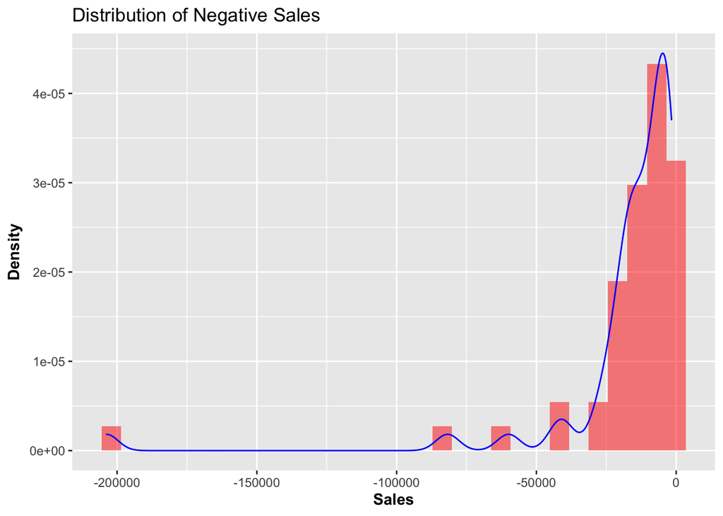

```r
# negative sales
ggplot(retail_neg_Weekly, aes(x = Sales)) +
  geom_histogram(aes(y = ..density..), fill = 'red', alpha = 0.5) +
  geom_density(colour = 'blue') +
  xlab(expression(bold('Sales'))) +
  ylab(expression(bold('Density'))) +
  ggtitle("Distribution of Negative Sales")
```

```r
# negative sales skewness & kurtosis
skewness(retail_neg_Weekly$Sales)
```

```
## [1] -4.867235
```

```r
kurtosis(retail_neg_Weekly$Sales)
```

```
## [1] 29.63872
```

## V. Modeling & Evaluation

A trend or seasonal component is common for gift sales. A decomposition of the model for the observed, trend, seasonal, and random components cannot be done because the data set only contains 13 months (less than two seasonal cycles of data).

### (i) Positive Sales

#### Time Series Model

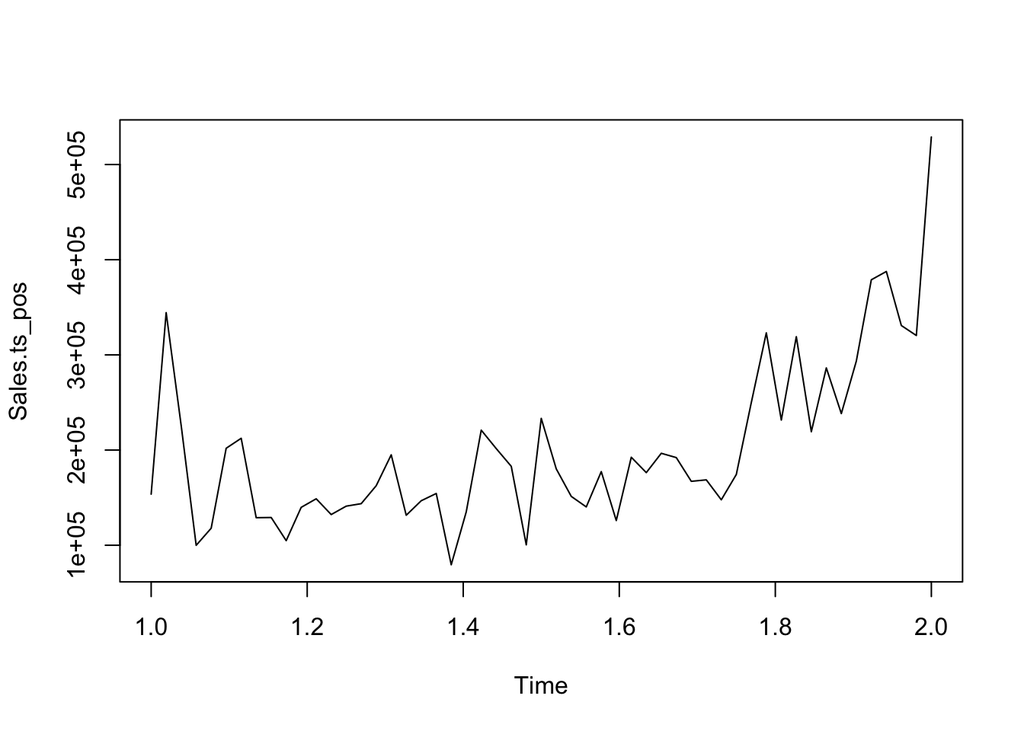

```r
Sales.ts_pos<-ts(retail_pos_Weekly$Sales,frequency=52)
plot(Sales.ts_pos)
```

#### Simple Moving Average

n=15 and 4 predictive points  
The next month of sales is predicted to total **$1,198,405**.

```r
Sales15_pos<-movavg_pred(retail_pos_Weekly$Sales,15,type="s",h=4)
sum(Sales15_pos[54:57])
```

```
## [1] 1198405
```

n=30 and 4 predictive points  
The next month of sales is predicted to total **$938,841.1**.

```r
Sales30_pos<-movavg_pred(retail_pos_Weekly$Sales,30,type="s",h=4)
sum(Sales30_pos[54:57])
```

```
## [1] 938841.1
```

n=50 and 4 predictive points  
The next month of sales is predicted to total **$801,493.8**.

```r
Sales50_pos<-movavg_pred(retail_pos_Weekly$Sales,50,type="s",h=4)
sum(Sales50_pos[54:57])
```

```
## [1] 801493.8
```

#### Exponential Smoothing

n=15 and 4 predictive points  
The next months of sales is predicted to total **$1,634,202**.

```r
Sales15e_pos<-movavg_pred(retail_pos_Weekly$Sales,15,type="e",h=4)
sum(Sales15e_pos[54:57])
```

```
## [1] 1634202
```

n=30 and 4 predictive points  
The next months of sales is predicted to total **$1,545,821**.

```r
Sales30e_pos<-movavg_pred(retail_pos_Weekly$Sales,30,type="e",h=4)
sum(Sales30e_pos[54:57])
```

```
## [1] 1545821
```

n=50 and 4 predictive points  
The next months of sales is predicted to total **$1,491,076**.

```r
Sales50e_pos<-movavg_pred(retail_pos_Weekly$Sales,50,type="e",h=4)
sum(Sales50e_pos[54:57])
```

```
## [1] 1491076
```

#### ARIMA

Optimal parameters for the ARIMA model are found using the auto.arima() function. Looking at the tsdisplay() output, the function gave good parameters.

The next months sales are predicted to total **$1,629,354**.

```r
auto.arima(retail_pos_Weekly$Sales)
```

```
## Series: retail_pos_Weekly$Sales
## ARIMA(0,1,1)
##
## Coefficients:
##           ma1
##       -0.6133
## s.e.   0.1077
##
## sigma^2 estimated as 3.825e+09:  log likelihood=-647.2
## AIC=1298.4   AICc=1298.64   BIC=1302.3
```

```r
SalesARIMA_pos<-arima(Sales.ts_pos,order=c(0,1,1))
SalesARIMA_pos
```

```
##
## Call:
## arima(x = Sales.ts_pos, order = c(0, 1, 1))
##
## Coefficients:
##           ma1
##       -0.6133
## s.e.   0.1077
##
## sigma^2 estimated as 3.751e+09:  log likelihood = -647.2,  aic = 1298.4
```

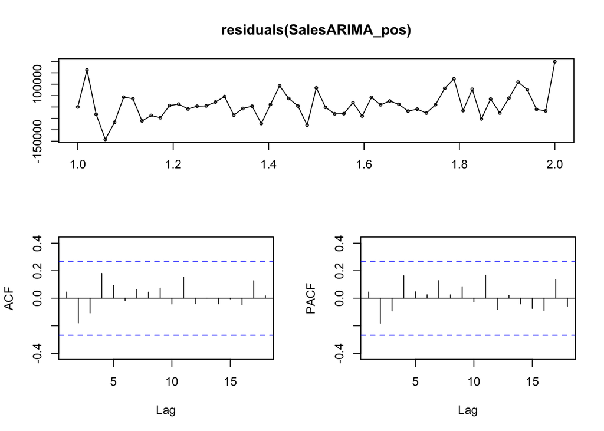

```r
tsdisplay(residuals(SalesARIMA_pos))
```

```r
SalesARIMA_pos_forecast<-forecast(SalesARIMA_pos,h=4)
SalesARIMA_pos_forecast
```

```
##          Point Forecast    Lo 80    Hi 80    Lo 95    Hi 95
## 2.019231       407338.5 328847.2 485829.8 287296.4 527380.6
## 2.038462       407338.5 323183.8 491493.2 278634.9 536042.1
## 2.057692       407338.5 317878.1 496798.9 270520.7 544156.3
## 2.076923       407338.5 312870.0 501807.0 262861.5 551815.6
```

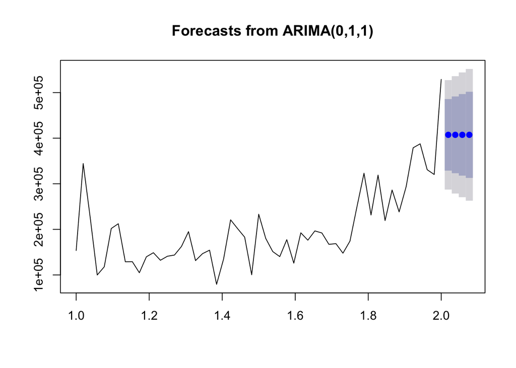

```r
plot(SalesARIMA_pos_forecast)
```

#### - EVALUATION -

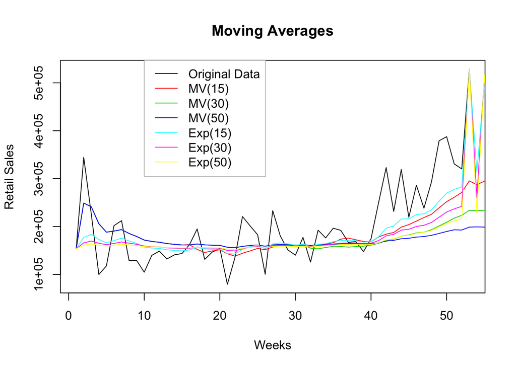

| Model | Average Prediction |
| --- | --- |
| Simple Moving Average | 979,580 |
| Exponential Smoothing | 1,557,033 |
| ARIMA | 1,629,354 |

```r
 plot(retail_pos_Weekly$Sales,type="l",col="1",main="Moving Averages",xlab="Weeks",ylab="Retail Sales")
 lines(Sales15_pos,col=2)
 lines(Sales30_pos,col=3)
 lines(Sales50_pos,col=4)
 lines(Sales15e_pos,col=5)
 lines(Sales30e_pos,col=6)
 lines(Sales50e_pos,col=7)
 legend(10,550000,c("Original Data","MV(15)","MV(30)","MV(50)","Exp(15)","Exp(30)","Exp(50)"),col=1:7,lty=1,lwd=1,box.col="gray",bg="white")
```

The predicted sales for the next 4 weeks are calculated using the exponential smoothing and simple moving average (using 15, 30, and 50 weeks in hindsight). The single moving averages with a higher window parameter produces a more stable model. Thus, the simple moving average model with 50 weeks in hindsight is more stable than the 30 and 15 week models.

From the time series visualizations of each week (see above), there is debate whether which algorithm is best for this problem. The MV(50) model performs well at the beginning of the time frame due to having 50 weeks hindsight. MV(50) predicts the smallest amount of sales for the next 4 weeks.

The Exp(15) model captures the trend and fluctuation of the sales data at the end of the time frame the best due to only considering 15 weeks hindsight. Exp(15) predicts the largest amount of sales for the next 4 weeks.

When considering the original data, the sales spark at the very beginning of the time frame, then remain constant for several weeks, then rise again at the end of the time frame. This may be a seasonal trend but, our data set contains less than 2 seasonal cycles of data, so seasonality cannot be determined.

When considering all the models, the average of the predictions shows that the Exponential Smoothing and ARIMA algorithms are agreeable in their predictions that the next 4 week’s sales data will be around $1.5 million. **We will choose either the Exponential Smoothing or ARIMA algorithm for future predictions. It is suggested that more data be collected for seasonality analysis, which will lead to better predictions**.

### (ii) Negative Sales

#### Time Series Model

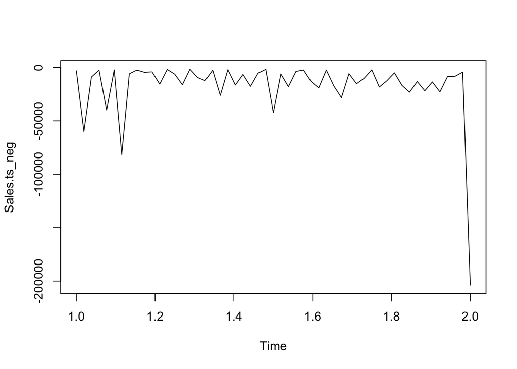

```r
Sales.ts_neg<-ts(retail_neg_Weekly$Sales,frequency=52)
plot(Sales.ts_neg)
```

#### Simple Moving Average

n=15 and 4 predictive points  
The next month of negative sales is predicted to total **$-105,506.60**.

```r
Sales15_neg<-movavg_pred(retail_neg_Weekly$Sales,15,type="s",h=4)
sum(Sales15_neg[54:57])
```

```
## [1] -105506.6
```

n=30 and 4 predictive points  
The next month of negative sales is predicted to total **$-78,125.51**.

```r
Sales30_neg<-movavg_pred(retail_neg_Weekly$Sales,30,type="s",h=4)
sum(Sales30_neg[54:57])
```

```
## [1] -78125.51
```

n=50 and 4 predictive points  
The next month of negative sales is predicted to total **$-67,694.15**.

```r
Sales50_neg<-movavg_pred(retail_neg_Weekly$Sales,50,type="s",h=4)
sum(Sales50_neg[54:57])
```

```
## [1] -67694.15
```

#### Exponential Smoothing

n=15 and 4 predictive points  
The next months of negative sales is predicted to total **$-441,156.30**.

```r
Sales15e_neg<-movavg_pred(retail_neg_Weekly$Sales,15,type="e",h=4)
sum(Sales15e_neg[54:57])
```

```
## [1] -441156.3
```

n=30 and 4 predictive points  
The next months of negative sales is predicted to total **$-435,185.70**.

```r
Sales30e_neg<-movavg_pred(retail_neg_Weekly$Sales,30,type="e",h=4)
sum(Sales30e_neg[54:57])
```

```
## [1] -435185.7
```

n=50 and 4 predictive points  
The next months of negative sales is predicted to total **$-432,179.90**.

```r
Sales50e_neg<-movavg_pred(retail_neg_Weekly$Sales,50,type="e",h=4)
sum(Sales50e_neg[54:57])
```

```
## [1] -432179.9
```

#### ARIMA

Optimal parameters for the ARIMA model are found using the auto.arima() function. Looking at the tsdisplay() output, the function gave good parameters.

```r
auto.arima(retail_neg_Weekly$Sales)
```

```
## Series: retail_neg_Weekly$Sales
## ARIMA(0,0,1) with non-zero mean
##
## Coefficients:
##           ma1        mean
##       -0.3798  -16014.910
## s.e.   0.2057    2617.385
##
## sigma^2 estimated as 876645037:  log likelihood=-619.94
## AIC=1245.88   AICc=1246.37   BIC=1251.79
```

```r
SalesARIMA_neg<-arima(Sales.ts_neg,order=c(0,0,1))
SalesARIMA_neg
```

```
##
## Call:
## arima(x = Sales.ts_neg, order = c(0, 0, 1))
##
## Coefficients:
##           ma1   intercept
##       -0.3798  -16014.910
## s.e.   0.2057    2617.385
##
## sigma^2 estimated as 843564092:  log likelihood = -619.94,  aic = 1245.88
```

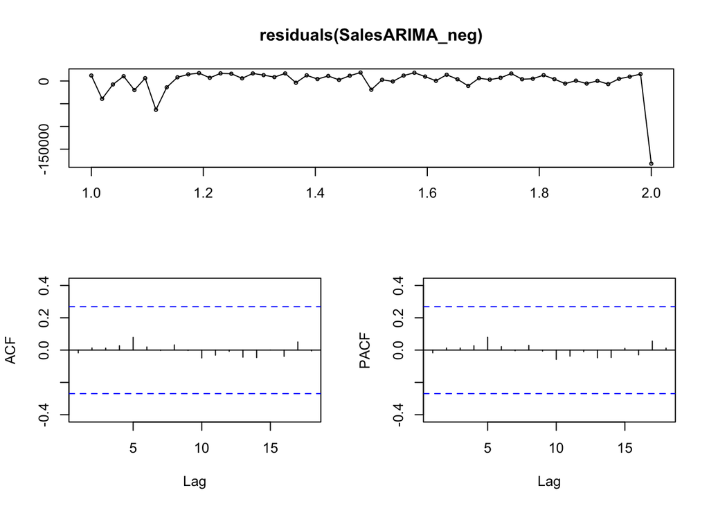

```r
tsdisplay(residuals(SalesARIMA_neg))
```

```r
SalesARIMA_neg_forecast<-forecast(SalesARIMA_neg,h=4)
SalesARIMA_neg_forecast
```

```
##          Point Forecast     Lo 80    Hi 80     Lo 95     Hi 95
## 2.019231       53110.66  15889.05 90332.26  -3814.88 110036.19
## 2.038462      -16014.91 -55830.98 23801.16 -76908.34  44878.52
## 2.057692      -16014.91 -55830.98 23801.16 -76908.34  44878.52
## 2.076923      -16014.91 -55830.98 23801.16 -76908.34  44878.52
```

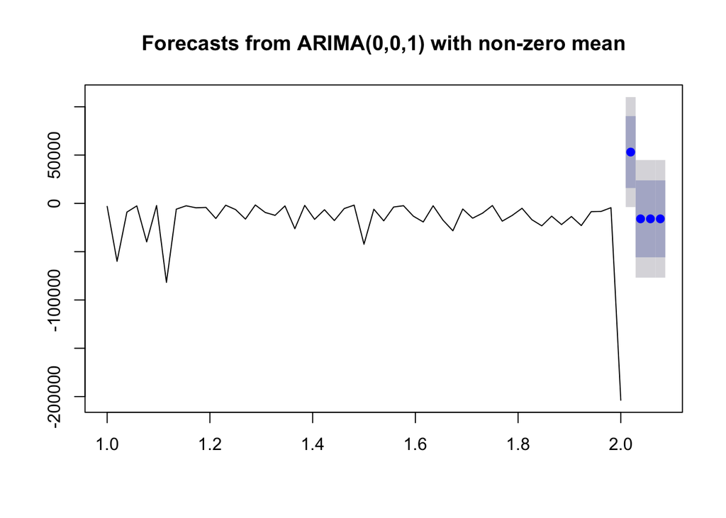

```r
plot(SalesARIMA_neg_forecast)
```

#### - EVALUATION -

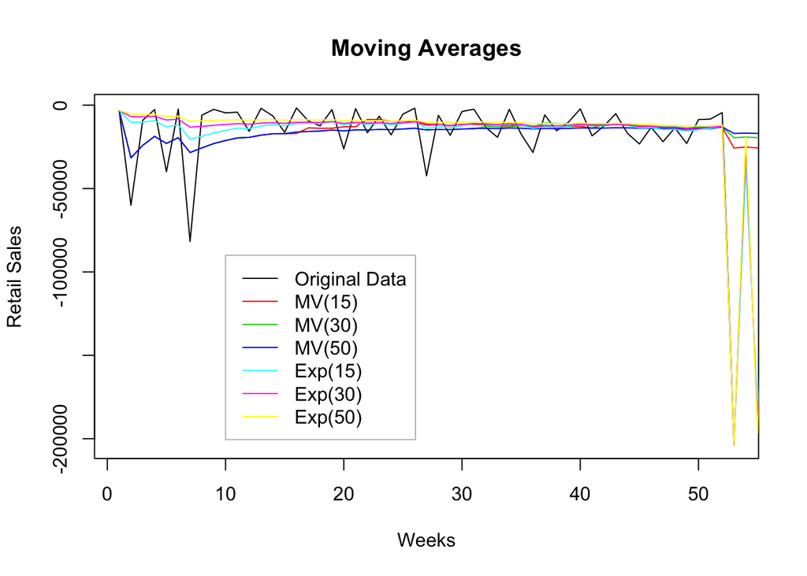

[output not shown]

```r
plot(retail_neg_Weekly$Sales,type="l",col="1",main="Moving Averages",xlab="Weeks",ylab="Retail Sales")
lines(Sales15_neg,col=2)
lines(Sales30_neg,col=3)
lines(Sales50_neg,col=4)
lines(Sales15e_neg,col=5)
lines(Sales30e_neg,col=6)
lines(Sales50e_neg,col=7)
legend(10,-90000,c("Original Data","MV(15)","MV(30)","MV(50)","Exp(15)","Exp(30)","Exp(50)"),col=1:7,lty=1,lwd=1,box.col="gray",bg="white")
```

The predicted negative sales for the next 4 weeks are calculated using the exponential smoothing and simple moving average (using 15, 30, and 50 weeks in hindsight). The single moving averages with a higher window parameter produces a more stable model. Thus, the simple moving average model with 50 weeks in hindsight is more stable than the 30 and 15 week models.

From the time series visualizations of each week (see above), there is debate whether which algorithm is best for this problem. The MV(50) model performs well at the beginning of the time frame due to having 50 weeks hindsight. MV(50) predicts the smallest amount of negative sales for the next 4 weeks.

All exponential models capture the drastic increase in negative sales at the end of the time frame. Because of this, the exponential model predictions are drastically different than simple and ARIMA models.

When considering the original data, the negative sales have a moderate increase at the beginning of the time frame, then remain constant for several weeks, then sharply increase again at the end of the time frame. The same pattern was followed with the positive sales.